# Satellite tag derived movements of Aus SRW at Kerguelen

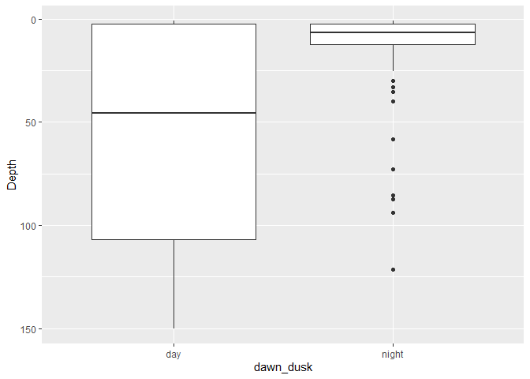

```r
 ggplot(kerg_dive_dd, aes(x=dawn_dusk, y=Depth)) +
  geom_boxplot()+
  scale_y_reverse()
```

I’ve used here, as the definition of day, all dives that occur between dawn and dusk (6 degree sun angle) - referred to as civil dusk/dawn/twilight.  
Mean dive depth during the day is 58.95 m with a range of 1 m to 150 m and a median depth of 45.5 m.  
Mean dive depth during the night is 12.56 m with a range of 1 m to 121.5 m and a median depth of 6.5 m.

**8- WHAT DOES THE HISTOGRAM DATA LOOK LIKE?** PTT 235414 was programmed to transmit summarised histogram data over 14 dive depth bins (10m, 20m, 30m, 40m, 50m, 75m, 100m, 125m, 150m, 200m, 250m, 300m, 350m, >350m), 9 dive duration bins (2 min, 3 min, 5 min, 10 min, 15 min, 20 min, 25 min, 30 min, > 30 min) and 14 time at depth depth bins (10m, 20m, 30m, 40m, 50m, 75m, 100m, 125m, 150m, 200m, 250m, 300m, 350m, >350m). Each bin value is the upper limit of the bin. These histograms summarised data over 6 hour intervals.

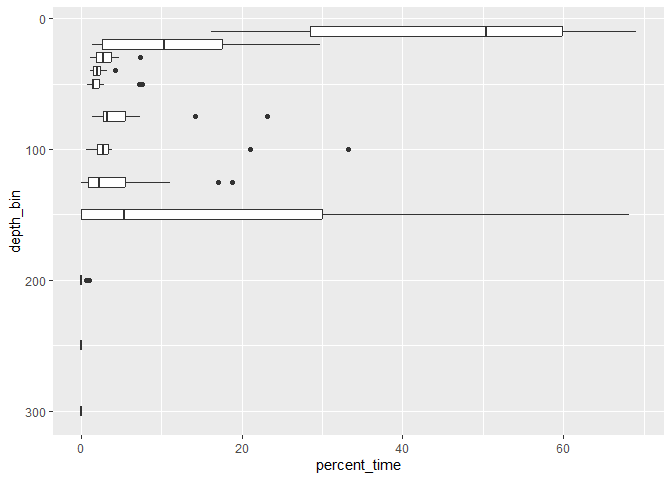

```r
histos_WA$Date <- as.POSIXct(histos_WA$Date, format = "%H:%M:%S %d-%b-%Y", tz="GMT")
histos_WA$in_area <- "no"
histos_WA$in_area[histos_WA$Date >= start & histos_WA$Date <= end] <- "yes"


TAD <- histos_WA[histos_WA$HistType=="TAD" & histos_WA$in_area=="yes",]

TAD_histo <- data.frame(c(rep(10, nrow(TAD)), rep(20,nrow(TAD)), rep(30,nrow(TAD)), rep(40,nrow(TAD)), rep(50,nrow(TAD)), rep(75,nrow(TAD)), rep(100,nrow(TAD)), rep(125,nrow(TAD)), rep(150,nrow(TAD)),rep(200,nrow(TAD)), rep(250,nrow(TAD)), rep(300,nrow(TAD)), rep(350,nrow(TAD)), rep(360,nrow(TAD))), c(TAD$Bin1, TAD$Bin2, TAD$Bin3,TAD$Bin4,TAD$Bin5,TAD$Bin6,TAD$Bin7,TAD$Bin8,TAD$Bin9,TAD$Bin10,TAD$Bin11,TAD$Bin12,TAD$Bin13,TAD$Bin14))
colnames(TAD_histo) <- c("depth_bin", "percent_time")

 ggplot(TAD_histo, aes(x=percent_time, y=depth_bin, group=depth_bin)) +
  geom_boxplot()+
  scale_y_reverse()
```

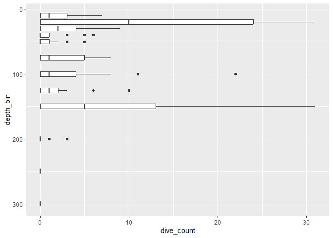

```r
DD <- histos_WA[histos_WA$HistType=="DiveDepth" & histos_WA$in_area=="yes",] #dive count per depth bin

DD_histo <- data.frame(c(rep(10, nrow(DD)), rep(20,nrow(DD)), rep(30,nrow(DD)), rep(40,nrow(DD)), rep(50,nrow(DD)), rep(75,nrow(DD)), rep(100,nrow(DD)), rep(125,nrow(DD)), rep(150,nrow(DD)),rep(200,nrow(DD)), rep(250,nrow(DD)), rep(300,nrow(DD)), rep(350,nrow(DD)), rep(360,nrow(DD))), c(DD$Bin1, DD$Bin2, DD$Bin3,DD$Bin4,DD$Bin5,DD$Bin6,DD$Bin7,DD$Bin8,DD$Bin9,DD$Bin10,DD$Bin11,DD$Bin12,DD$Bin13,DD$Bin14))
colnames(DD_histo) <- c("depth_bin", "dive_count")

 ggplot(DD_histo, aes(x=dive_count, y=depth_bin, group=depth_bin)) +
  geom_boxplot()+
  scale_y_reverse()
```

The dive depth boxplot gives the number of dives occuring in each depth bin per 6h summary window. There are 13 6h summary histograms for dive counts in depth bins. This time we can see the high number of dives occurring in the 10m to 20m bin and the 125m to 150m bin.

Here we can see that the histogram summaries have captured more data than the time series data that we looked at above with 4 dives occurring in the 150m to 200m depth bin.

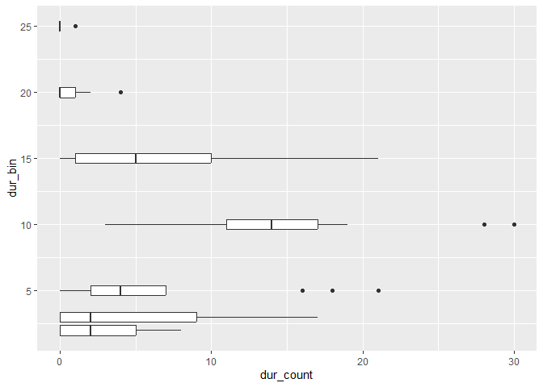

```r
DDur <- histos_WA[histos_WA$HistType=="DiveDuration" & histos_WA$in_area=="yes",] #dive duration count per depth bin


DDur_histo <- data.frame(c(rep(2, nrow(DDur)), rep(3,nrow(DDur)), rep(5,nrow(DDur)), rep(10,nrow(DDur)), rep(15,nrow(DDur)), rep(20,nrow(DDur)), rep(25,nrow(DDur)), rep(30,nrow(DDur)), rep(31,nrow(DDur))), c(DDur$Bin1, DDur$Bin2, DDur$Bin3,DDur$Bin4,DDur$Bin5,DDur$Bin6,DDur$Bin7,DDur$Bin8,DDur$Bin9))
colnames(DDur_histo) <- c("dur_bin", "dur_count")

 ggplot(DDur_histo, aes(x=dur_count, y=dur_bin, group=dur_bin)) +
  geom_boxplot()
```

**9- DIVE BEHAVIOR WITHIN HIGH TIME SPENT GRID CELLS?**  
We can discuss dive behaviour is a general sense around Kerguelen and take a look at what the dive data sets hold for the time periods within the higher time spent grid cells. The dive files to check are: behav_WA, series_WA, histos_WA. The grid cells focused on here are 22947 (7.8 days) and 23621 (2 days).

```r
dive_check <- data.frame("grid_cell"=c(rep("22947", 5), rep("23621",1)), "start" = as.POSIXct(c("2023-01-26 02:55:07", "2023-01-28 02:09:07", "2023-01-31 00:58:51", "2023-02-04 03:13:25", "2023-02-06 01:11:16", "2023-01-20 16:28:47"), tz="UTC"), "end" = as.POSIXct(c("2023-01-27 03:31:38", "2023-01-29 03:47:03", "2023-02-01 02:36:54", "2023-02-05 01:43:19", "2023-02-08 01:07:07", "2023-01-22 03:28:20"), tz="UTC"))

## behaviour data set
behav_bind <- behav_WA[1,]
behav_bind$grid_cell <- 999

for (i in 1:nrow(dive_check)){
sub <- behav_WA[as.POSIXct(behav_WA$Start) >= as.POSIXct(dive_check$start[i]) & as.POSIXct(behav_WA$End) <= as.POSIXct(dive_check$end[i]),]

if (nrow(sub)==0) {
  next
}

sub$grid_cell <- dive_check$grid_cell[i]

behav_bind <- rbind(behav_bind, sub)
}

behav_tsp <- behav_bind[-1,]

##histos data set

histos_bind <- histos_WA[1,]
histos_bind$grid_cell <- 999

for (i in 1:nrow(dive_check)){
sub <- histos_WA[as.POSIXct(histos_WA$Date) >= as.POSIXct(dive_check$start[i]) & as.POSIXct(histos_WA$Date + 60*60*6) <= as.POSIXct(dive_check$end[i]),]

if (nrow(sub)==0) {
  next
}

sub$grid_cell <- dive_check$grid_cell[i]

histos_bind <- rbind(histos_bind, sub)
}

histos_tsp <- histos_bind[-1,]

##time series data set
series_bind <- series_WA[1,]
series_bind$grid_cell <- 999

for (i in 1:nrow(dive_check)){
sub <- series_WA[as.POSIXct(series_WA$gmt) >= as.POSIXct(dive_check$start[i]) & as.POSIXct(series_WA$gmt) <= as.POSIXct(dive_check$end[i]),]

if (nrow(sub)==0) {
  next
}

sub$grid_cell <- dive_check$grid_cell[i]

series_bind <- rbind(series_bind, sub)
}

series_tsp <- series_bind[-1,]
```

**Behaviour in high time spent grid cells**  
Distribution of dive shapes within the high time spent grid cells:

```r
shape_tsp <- behav_tsp[behav_tsp$What=="Dive",]

table(shape_tsp$Shape) ## few V dive shapes
```

```
##
## Square      U      V
##     27     20      8
```

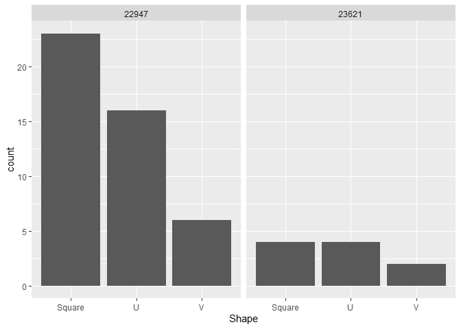

```r
p_shp <- ggplot(shape_tsp) + geom_bar(aes(x = Shape))

p_shp + facet_grid(~grid_cell)
```

Dip into dive durations - note duration is given in seconds so it appears in plots as /60 to provide the minutes equivalent.

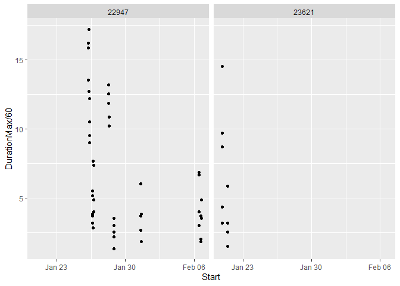

```r
p_dur <- ggplot(shape_tsp, aes(Start, DurationMax/60)) + geom_point()
p_dur + facet_grid(~grid_cell)
```

What is the maximum dive time here?

```r
max(shape_tsp$DurationMax)/60
```

```
## [1] 17.18333
```

The longest dive occurs within grid cell 22947 (the 7.8 day time spent grid).

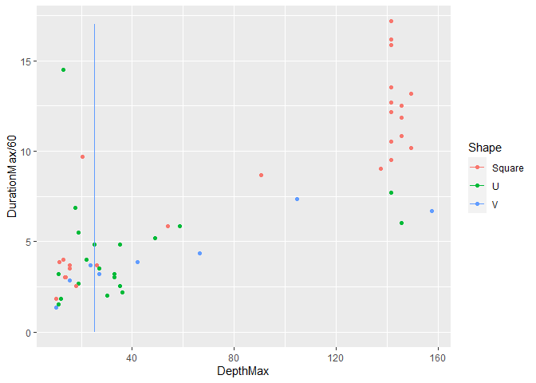

```r
p_dd_tsp <- ggplot(shape_tsp, aes(DepthMax, DurationMax/60, colour=Shape)) + geom_point() + geom_segment((aes(x=25, xend=25, y=0, yend=17)))
p_dd_tsp
```

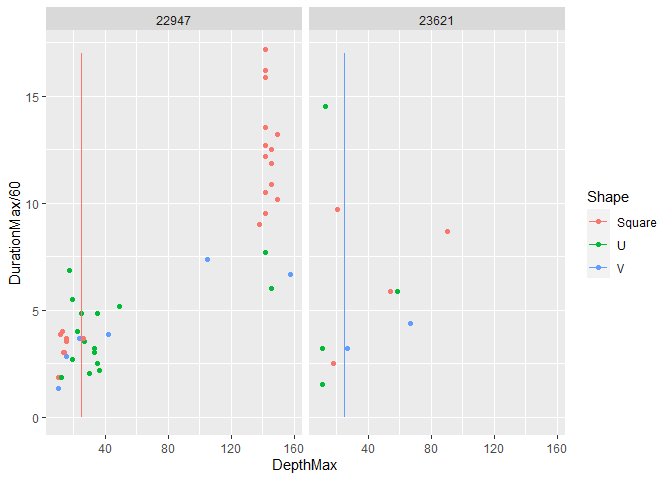

```r
p_dd_tsp + facet_grid(~grid_cell)
```

Longer and deeper dives appear to be mostly square shaped and mostly occur in grid cell 22947.  
When we took a look at the bathymetric characteristics of 22947 and 23621 by extracting the bathymetric depth at each location in each cell, the locations occurred over a mean depth of 143.5 m (range: 119 to 163m; median: 144m) in 22957 and a mean depth of 92.7m (range: 85 to 101m; median:93m) in 23621. We might assume, especially for grid cell 22947, that the whale is diving close to the sea floor.

For grid cell 22947, there appears to be a bi modal pattern of diving - shallow dives at less than 40m and around 7 mins or less in duration versus deeper dives around 140m and deeper at a duration of greater than 7 mins.  
**Time series in high time spent grid cells**

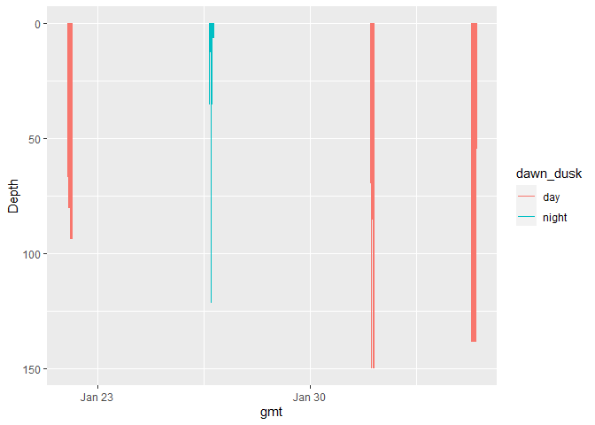

```r
## Now assign dives to within dusk and dawn or not - dd_day will indicate whether located between dusk and dawn
## remember to set all out of area to NA
## also need to use local time...(UTC + 5)

dtes <- unique(as.Date(series_tsp$gmt + 5*60*60))

series_bind <- series_tsp[1,]
series_bind$dawn_dusk <- "to assign"

for(i in 1:length(dtes)){
  sub_series <- series_tsp[as.Date(series_tsp$gmt + 5*60*60) == dtes[i],]
  sr_ss_match <- sr_ss[sr_ss$ref_date==dtes[i],]
  sub_series$dawn_dusk <- "night"
  sub_series$dawn_dusk[sub_series$gmt+ 5*60*60 >= sr_ss_match$civil_dawn+ 5*60*60 & sub_series$gmt+ 5*60*60 <= sr_ss_match$civil_dusk+ 5*60*60] <- "day"
  series_bind <- rbind(series_bind,sub_series)

}

tsp_dive_dd <- series_bind[-1,]

p_tsp_series <- ggplot(tsp_dive_dd, aes(gmt, Depth)) +
  geom_segment(aes(x=gmt, xend=gmt, y=0, yend=Depth, colour=dawn_dusk)) +
  scale_y_reverse()
p_tsp_series
```

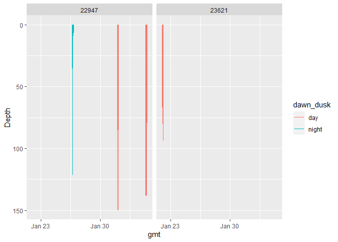

```r
p_tsp_series + facet_grid(~grid_cell)
```

The data transmitted was mostly related to dives occurring during the day.  
**Histograms in high time spent grid cells**

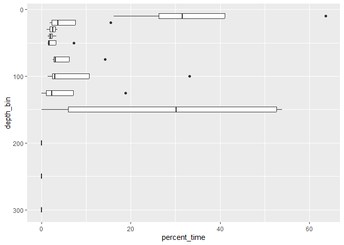

```r
TAD_tsp <- histos_tsp[histos_tsp$HistType=="TAD",]

TAD_tsp_histo <- data.frame(c(rep(10, nrow(TAD_tsp)), rep(20,nrow(TAD_tsp)), rep(30,nrow(TAD_tsp)), rep(40,nrow(TAD_tsp)), rep(50,nrow(TAD_tsp)), rep(75,nrow(TAD_tsp)), rep(100,nrow(TAD_tsp)), rep(125,nrow(TAD_tsp)), rep(150,nrow(TAD_tsp)),rep(200,nrow(TAD_tsp)), rep(250,nrow(TAD_tsp)), rep(300,nrow(TAD_tsp)), rep(350,nrow(TAD_tsp)), rep(360,nrow(TAD_tsp))), c(TAD_tsp$Bin1, TAD_tsp$Bin2, TAD_tsp$Bin3,TAD_tsp$Bin4,TAD_tsp$Bin5,TAD_tsp$Bin6,TAD_tsp$Bin7,TAD_tsp$Bin8,TAD_tsp$Bin9,TAD_tsp$Bin10,TAD_tsp$Bin11,TAD_tsp$Bin12,TAD_tsp$Bin13,TAD_tsp$Bin14))
colnames(TAD_tsp_histo) <- c("depth_bin", "percent_time")

TAD_tsp_histo$grid_cell <- rep(TAD_tsp$grid_cell, 14) #14 bins

 p_TAD_tsp <- ggplot(TAD_tsp_histo, aes(x=percent_time, y=depth_bin, group=depth_bin)) +
  geom_boxplot()+
  scale_y_reverse()

  p_TAD_tsp
```

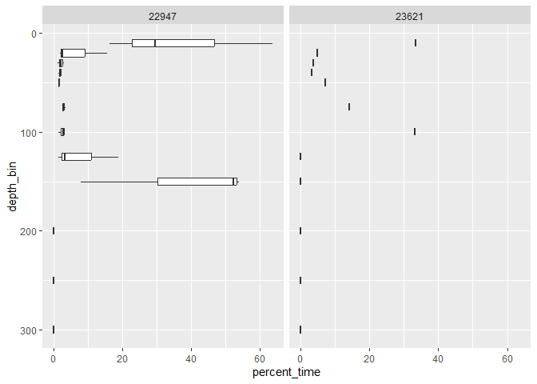

```r
 p_TAD_tsp + facet_grid(~grid_cell)
```

Similar to the overall data set - dives concentrated in depths < 20m and at around 125 to 150m.

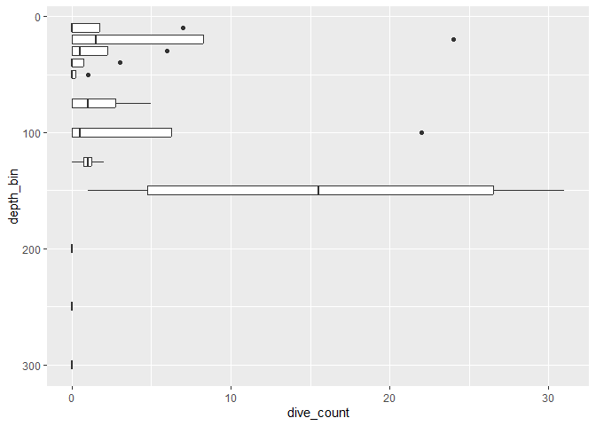

```r
DD_tsp <- histos_tsp[histos_tsp$HistType=="DiveDepth",] #dive count per depth bin

DD_tsp_histo <- data.frame(c(rep(10, nrow(DD_tsp)), rep(20,nrow(DD_tsp)), rep(30,nrow(DD_tsp)), rep(40,nrow(DD_tsp)), rep(50,nrow(DD_tsp)), rep(75,nrow(DD_tsp)), rep(100,nrow(DD_tsp)), rep(125,nrow(DD_tsp)), rep(150,nrow(DD_tsp)),rep(200,nrow(DD_tsp)), rep(250,nrow(DD_tsp)), rep(300,nrow(DD_tsp)), rep(350,nrow(DD_tsp)), rep(360,nrow(DD_tsp))), c(DD_tsp$Bin1, DD_tsp$Bin2, DD_tsp$Bin3,DD_tsp$Bin4,DD_tsp$Bin5,DD_tsp$Bin6,DD_tsp$Bin7,DD_tsp$Bin8,DD_tsp$Bin9,DD_tsp$Bin10,DD_tsp$Bin11,DD_tsp$Bin12,DD_tsp$Bin13,DD_tsp$Bin14))
colnames(DD_tsp_histo) <- c("depth_bin", "dive_count")

DD_tsp_histo$grid_cell <- rep(DD_tsp$grid_cell, 14) #14 bins

p_DD_tsp <-  ggplot(DD_tsp_histo, aes(x=dive_count, y=depth_bin, group=depth_bin)) +
  geom_boxplot()+
  scale_y_reverse()

p_DD_tsp
```

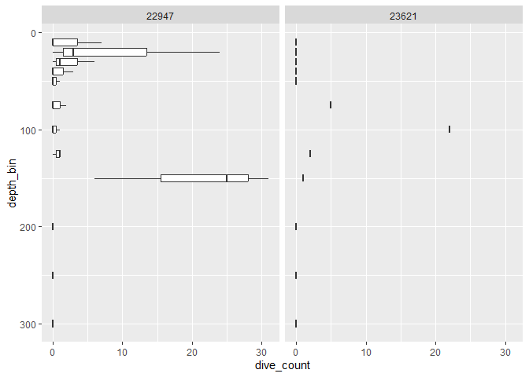

```r
p_DD_tsp + facet_grid(~grid_cell)
```

The dive count boxplot gives the number of dives occurring in each depth bin per 6h summary window. This time we can see the high number of dives occurring in the 125m to 150m bin.

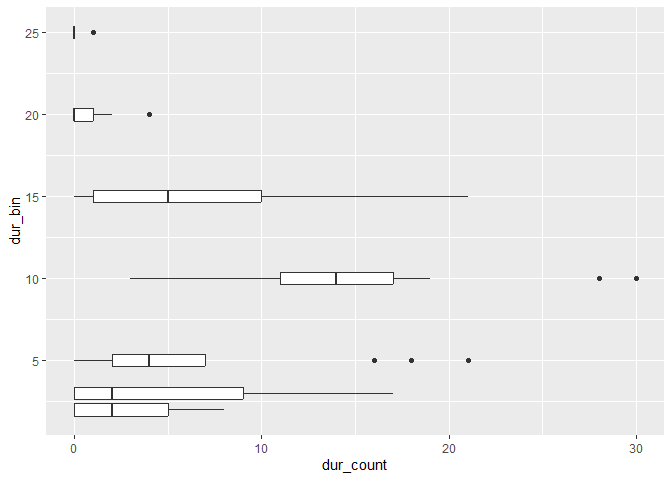

```r
DDur_tsp <- histos_tsp[histos_tsp$HistType=="DiveDuration",] #dive duration count per depth bin


DDur_tsp_histo <- data.frame(c(rep(2, nrow(DDur_tsp)), rep(3,nrow(DDur_tsp)), rep(5,nrow(DDur_tsp)), rep(10,nrow(DDur_tsp)), rep(15,nrow(DDur_tsp)), rep(20,nrow(DDur_tsp)), rep(25,nrow(DDur_tsp)), rep(30,nrow(DDur_tsp)), rep(31,nrow(DDur_tsp))), c(DDur_tsp$Bin1, DDur_tsp$Bin2, DDur_tsp$Bin3,DDur_tsp$Bin4,DDur_tsp$Bin5,DDur_tsp$Bin6,DDur_tsp$Bin7,DDur_tsp$Bin8,DDur_tsp$Bin9))
colnames(DDur_histo) <- c("dur_bin", "dur_count")

DDur_tsp_histo$grid_cell <- rep(DDur_tsp$grid_cell, 9) #9 bins

 p_DDur_tsp <- ggplot(DDur_histo, aes(x=dur_count, y=dur_bin, group=dur_bin)) +
  geom_boxplot()

  p_DDur_tsp
```

```r
#save(list=ls(all=TRUE), file = paste(file.path(here::here('Outputs')), "/working_file.Rdata", sep=""))
```